# Model Fitting

Wataru Toyokawa

06/01/2021

# Bridging a gulf between theory and experiment

An individual-based computational models might often be mathematically less tractable compared to the population-level dynamical modelling approach. On the other hand, a population dynamics model hardly captures individual decision-making processes while an individual-based model is capable of capturing individual decisions and interactions very well. To bridge a gap between theory of collective behaviour and empirical knowledge about social behaviour, therefore, we need both approaches.

In this practical session, I will introduce how to connect behavioural data to your computational models.[^1] To be honest, this tutorial will not cover any state-of-art modern methods of model fitting and analysis (e.g. hierarchical Bayesian estimation, MCMC sampling, reparameterization techniques, etc), but will only describe how to calculate log-likelihood of your model. Though I believe the calculation of log-likelihood should necessarily be the first step of model fitting, further readings and practices may be required if you want to employ a mod-based analysis in your own study. [Statistical Rethinking](https://xcelab.net/rm/statistical-rethinking/) is really a nice textbook for general introduction of statistical model-based analysis. For computational-modelling of behavioural science, [this tutorial paper](https://elifesciences.org/articles/49547) is fantastic and highly recommended. For Japanese readers, [『行動データの計算論的モデリング』](https://www.amazon.co.jp/dp/B07HYSQYN2/ref=dp-kindle-redirect?_encoding=UTF8&btkr=1) is one of the must-read.

# Generating a pseudo behavioural data by simulation

Alrigh, let’s get started. The brief sketch of this practice is summarise in this [slide](https://www.slideshare.net/WataruToyokawa1/chain-winter-2021-tutorial-2).

First thing we need is data. Without data, we cannot fit nothing. Also in practice, since the parameter recovery check is the recommended first step of model-based study, we normally set out to generate pseudo simulated data using the candidate models before running actual behavioural experiments.

I will again use the two-armed risky bandit task in this demo. The task setting is as follows:

```r
group_size = 4
num_options = 2 # the number of options
horizon = 100 # total trial number in one session
Q_initial = 1.25 # neutral prior belief
# mean and s.d. values for two, sure and risky alternatives
mean_list = c(1, 1.5)
sd_list = c(0.03, 1)
```

## Setting parameter values

We will simulate 4 individuals. Their parameter values are:

```r
# individual parameters
this_alpha <- c(0.1, 0.2, 0.4, 0.6)
this_beta <- c(10, 8, 6, 4)
```

## Running the model

Now we have defined both task and individuals. It’s time to run the model.[^2]

```r
# The initial status of the five innocent participants
Q <- array(dim = c(num_options, horizon, group_size))
Q[,1,] <- Q_initial # Q_initial = 1.25
netChoiceProb <- array(dim = c(num_options, horizon, group_size))
netChoiceProb[,1,] <- 1/num_options
choices <- matrix(nrow=group_size, ncol=horizon)
payoffs <- matrix(nrow=group_size, ncol=horizon)
riskyChoiceProb <- matrix(nrow=group_size, ncol=horizon)

for (t in 1:horizon) {
  # each individual chooses one option based on his/her choice probability netChoiceProb[,t,]
  choices[,t] <- apply(netChoiceProb[,t,]
                       , MARGIN = 2
                       , function(netChoiceProbInstance){
                                sample(1:num_options
                                       , 1
                                       , prob=netChoiceProbInstance
                                       , replace=FALSE
                                )
                         }
                        )

  # each subject earns payoffs whose amount depends upon choices[,t]
  payoffs[,t] <- mapply(rnorm, 1, mean_list[choices[,t]], sd_list[choices[,t]])

  if (t < horizon) {
    # Rescorla-Wagner updating rule: Q_next <- Q + alpha * (payoff - Q)
    Q <- rescorla_wagner_updating(t
                                 , numoptions
                                 , group_size
                                 , horizon
                                 , this_alpha
                                 , choices[,t]
                                 , payoffs[,t]
                                 , Q
                                 )


    ###############
    ## Softmax choice base solely on Q values
    ###############
    # Calculate each "exp( beta*Q_i )"
    Q_exp = ( Q[,t+1,] * rep(this_beta, each = num_options) ) %>% exp()
    # Then, calculating the softmax probability
    # exp( beta*Q_k )/(exp( beta*Q_1 ) + exp( beta*Q_2 )) for each slot
    softmaxMatrix = Q_exp %>%
      apply(MARGIN=1, divideVector, denominator = apply(Q_exp, MARGIN=2, sum)) %>%
      t()
    ## The followings update the choice probability matrix
    ###############
    ## Softmax -- END
    ###############

    netChoiceProbAperm = aperm(netChoiceProb, c(1,3,2))
    dim(netChoiceProbAperm) = c(num_options*group_size, horizon)
    dim(softmaxMatrix) = c(num_options*group_size, 1)
    netChoiceProbAperm[,t+1] = softmaxMatrix
    dim(netChoiceProbAperm) = c(num_options, group_size, horizon)
    netChoiceProb = aperm(netChoiceProbAperm, c(1,3,2))
  }
}
# Hooooray! One simulation run is done by now.
# Next, we need to record this result
# First, let's summarise this run:
for(i in 1:group_size) {
   riskyChoiceProb[i,] <- netChoiceProb[2,,i]
}
```

### Result of this session

The simulation has generated a series of choices which is shown as follows:

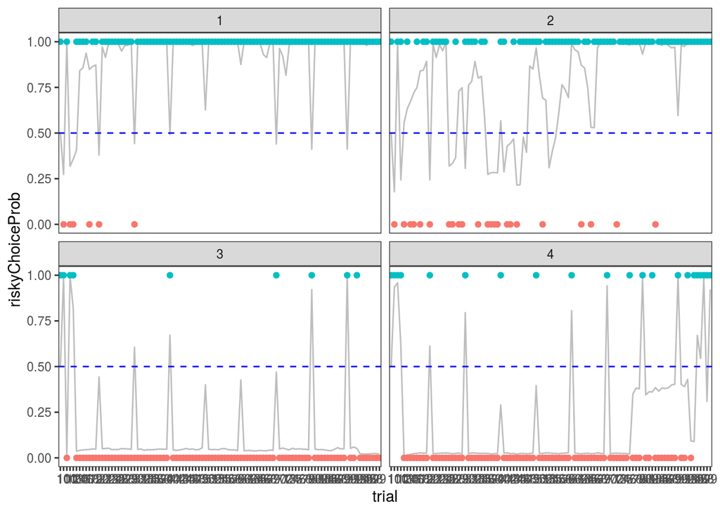

```r
speudo_data <- data.frame(riskyChoiceProb = riskyChoiceProb) %>%
  cbind(data.frame(choices = choices)) %>%
  cbind(data.frame(payoffs = payoffs)) %>%
  tidyr::pivot_longer(everything()
                      , names_to = c(".value", "trial")
                      , names_pattern = "([A-Za-z]+).(\\d+)"
                      )
speudo_data$indiv <- rep(1:group_size, each = horizon)

speudo_data %>%
  ggplot() +
  geom_line(aes(trial, riskyChoiceProb, group = indiv), colour='grey') +
  geom_point(aes(trial, choices-1, colour = as.factor(choices)))+
  geom_hline(yintercept = 0.5, linetype = 'dashed', colour = 'blue')+
  facet_wrap(~indiv)+
  theme_test()+
  theme(legend.position = 'NaN')
```

The pseudo-data looks like this:

```r
knitr::kable(head(speudo_data, 12), "simple")
```

| trial | riskyChoiceProb | choices | payoffs | indiv |
| --- | --- | --- | --- | --- |
| 1 | 0.5000000 | 2 | 0.7569454 | 1 |
| 2 | 0.3791742 | 1 | 0.9885664 | 1 |
| 3 | 0.4423522 | 1 | 1.0239866 | 1 |
| 4 | 0.4920629 | 2 | 1.7501080 | 1 |
| 5 | 0.6266010 | 2 | 2.6878383 | 1 |
| 6 | 0.8754319 | 2 | -0.7929438 | 1 |
| 7 | 0.4398095 | 2 | 1.0638094 | 1 |
| 8 | 0.4114918 | 2 | 1.1708002 | 1 |
| 9 | 0.4121484 | 2 | 0.5468997 | 1 |
| 10 | 0.2735765 | 1 | 0.9898705 | 1 |
| 11 | 0.3180923 | 1 | 1.0040060 | 1 |
| 12 | 0.3579923 | 1 | 0.9666321 | 1 |

Note that the `riskyChoiceProb` in the `psudo_data` contains **true values** which are not directly observable in behavioural experiments. Also, we know all the parameter values for each individual because we have defined them at the outset. The goal of our model would be to recover these true values as much as possible.

## Estimating log-likelihood

The next step is fitting the learning model with this pseudo data. Regardless of whatever method you use in model fitting, parameter fitting consists of only the following two steps.

1. Setting a parameter value
2. Calculating log-likelihood

That’s it. Let me walk through them one by one.

### 1. Setting a parameter value

Although we already know the truth, pretending not knowing any parameter values at all is an important requirement here. We will try to recover the true values.[^3]

Let’s say we start our exploration for the better fitting parameters with the following values:

```r
alpha_test <- c(0.5, 0.5, 0.5, 0.5) # learning rate values
beta_test <- c(5, 5, 5, 5) # inverse temperature
```

### 2. Calculating a log-likelihood

The next step is to calculate log-likelihood. Code of likelihood calculation might resemble that of an agent-based simulation. But unlike the simulation, we have already had a series of `choice[,t]` and `payoffs[,t]`.

```r
# picking up one individual
this_individual <- 1
data_this_individual <- speudo_data %>% dplyr::filter(indiv == this_individual)
this_choices <- data_this_individual$choices
this_payoffs <- data_this_individual$payoffs
this_alpha <- alpha_test[this_individual]
this_beta <- beta_test[this_individual]

# initial setting
Q <- matrix(rep(NA, num_options * horizon), nrow = num_options)
logChoiceProb_estimated <- matrix(rep(NA, num_options * horizon), nrow = num_options)
Q[,1] <- Q_initial # Note: this initial value can also be a subject of estimation
logChoiceProb_estimated[,1] <- log(1/num_options) # random choice at the 1st trial
logLik <- rep(0, horizon)
```

```r
# calculating log-likelihood
for (t in 1:horizon) {
  # recording the log likelihood of the choice made at this trial
  logLik[t] <- logChoiceProb_estimated[this_choices[t], t]

  # calculating the choice probability for the following trial
  if (t < horizon) {
    # copying Q values to the next trial
    Q[,t+1] <- Q[,t]

    # Rescorla-Wagner Updating for the chosen option
    Q[this_choices[t],t+1] <-
      Q[this_choices[t],t] +
      this_alpha * (this_payoffs[t] - Q[this_choices[t],t])

    # Softmax transformation (log based)
    logChoiceProb_estimated[,t+1] <-
      this_beta * Q[, t+1] - log( exp(this_beta * Q[, t+1]) %>% sum() )
  }
}

# the sum of log-likelihood
sum(logLik)
```

```
## [1] -32.49327
```

Note that the softmax function was calculated in a log form:

$\log \frac{\exp(\beta Q_{i,t})}{\sum \exp(\beta Q_{k,t})} = \beta Q_{i,t} - \log(\sum \exp(\beta Q_{k,t}))$

This was theoretically unnecessary, but would be a help when the raw probability underflows.

## The brute force method of parameter estimation

The log likelihood value above does not tell you how good or how bad the picked parameter values (i.e. $\alpha = 0.5$ and $\beta = 5$) can account for the data. Maybe other combinations of $\alpha$ and $\beta$ are better than this.

Theoretically, you can explore for the better combination by a brute force method by which the entire (or reasonably possible) region of parameter combinations are thoroughly searched.

Again, I will focus only on the first individual.

```r
first_individual_logliks <-
  data.frame(
    alpha = rep(seq(0, 1, 0.05), each = 21)
    , beta = rep(seq(0, 20, 1), 21)
    , logLik = rep(NA, 21^2)
  )
```

```r
# The brute force method of parameter estimation
for (this_alpha in seq(0, 1, 0.05)) {
  for (this_beta in seq(0, 20, 1)) {
    # initial setting
    Q <-matrix(rep(NA, num_options * horizon), nrow = num_options)
    logChoiceProb_estimated <-
      matrix(rep(NA, num_options * horizon), nrow = num_options)
    Q[,1] <- Q_initial
    logChoiceProb_estimated[,1] <- log(1/num_options)
    logLik <- rep(0, horizon)

    # calculating log-likelihood
    for (t in 1:horizon) {
      # recording the log likelihood of the choice made at this trial
      logLik[t] <- logChoiceProb_estimated[this_choices[t], t]

      # calculating the choice probability for the following trial
      if (t < horizon) {
        # copying Q values to the next trial
        Q[,t+1] <- Q[,t]

        # Rescorla-Wagner Updating for the chosen option
        Q[this_choices[t],t+1] <-
          Q[this_choices[t],t] +
          this_alpha * (this_payoffs[t] - Q[this_choices[t],t])

        # Softmax transformation (log based)
        logChoiceProb_estimated[,t+1] <-
          this_beta * Q[, t+1] - log( exp(this_beta * Q[, t+1]) %>% sum() )
      }
    }

    # the sum of log-likelihood
    first_individual_logliks$logLik[which(first_individual_logliks$alpha == this_alpha & first_individual_logliks$beta == this_beta)] <- sum(logLik)
  }
}
```

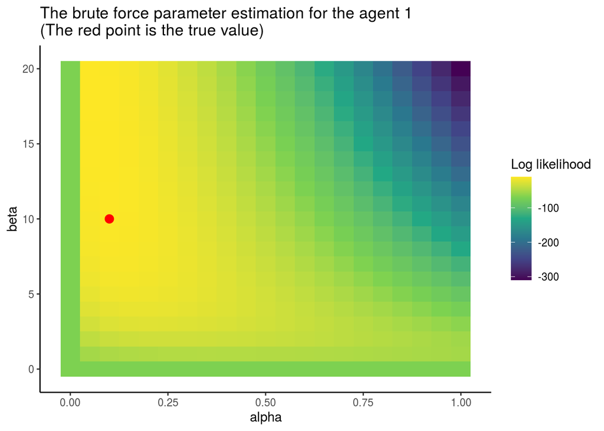

```r
first_individual_logliks %>% ggplot() +
  geom_tile(aes(alpha, beta, fill = logLik)) +
  geom_point(data=data.frame(alpha=0.1, beta=10), mapping=aes(alpha,beta), size = 3, colour='red')+
  scale_fill_viridis_c('Log likelihood')+
  labs(title = 'The brute force parameter estimation for the agent 1\n(The red point is the true value)')+
  theme_classic()
```

That’s it. How hard could it be? This maximum log likelihood method has been widely used, but often criticised for its unreliability. Thought the brute force method above gave a rough estimation which was more or less correct, it suggests a wide range of likely $\beta$ values (i.e. the yellow-ish area ranges widely along the $\beta$-axis in the low $\alpha$ area.).

This is why we need more sophisticated method to reliably infer the experimental data.

Through such a parameter recovery check, we can set out to plan how may subject, how many trials per subject, and how many groups we would need to achieve an acceptable reliability in the behavioural experiment.

[^1]: I won’t be able to discuss much about how to connect agent-based models to population-level dynamics models due to the limited time allowed me here. Also, such a connection has still been rare in behavioural science. I think this is really a fascinating future direction.
[^2]: Note that I have manually picked up parameter values for each individuals rather than randomly generating them. This was just for the sake of tractability of this demonstration. In practice, we might assume a probability distribution from which each individual value drops. The probability distribution will then be estimated through a hierarchical statistical method.
[^3]: In practice, however, you might have a reasonable prior knowledge, such as that the inverse temperature of softmax choice $\beta$ is seldom larger than 100. In that case, you should use such knowledge. It can dramatically improve the model fitting convergence.